# CNN_CIFAR (2)

###### 1.1.1 Importing libraries

```python
#Importing libraries
import tensorflow as tf
print(tf.__version__)
import scipy
import numpy as np
import pandas as pd
from scipy import optimize
from tensorflow import keras
import IPython.display
import PIL.Image
from tensorflow.keras import models
from tensorflow.keras import layers
import matplotlib.pyplot as plt
from keras.utils import to_categorical
from tensorflow.keras import optimizers
from tensorflow.keras.callbacks import TensorBoard
from keras import regularizers
from keras.optimizers import Adam
from keras.optimizers import RMSprop
from keras.models import Sequential,Input,Model
from keras.layers import Conv2D, MaxPooling2D, Input, Lambda, Flatten
from keras.callbacks import ReduceLROnPlateau, LearningRateScheduler, ModelCheckpoint
from keras.preprocessing.image import ImageDataGenerator
from keras.applications.vgg16 import preprocess_input
from keras import backend as K
import os
from keras.regularizers import l2
from keras.layers import Dense, Conv2D, BatchNormalization, Activation



#Clear any logs from previous runs
#import datetime
#!rm -rf ./logs/
```

```
2.2.0
```

###### 1.1.2 Loading fashion_mnist data

```python
#Loading and splitting the data
from tensorflow.keras.datasets import fashion_mnist
(train_images, train_labels), (test_images, test_labels) = fashion_mnist.load_data()

#Class names list
class_names = ['T-shirt/top', 'Trouser', 'Pullover', 'Dress', 'Coat',
               'Sandal', 'Shirt', 'Sneaker', 'Bag', 'Ankle boot']
```

```
Downloading data from https://storage.googleapis.com/tensorflow/tf-keras-datasets/train-labels-idx1-ubyte.gz
Downloading data from https://storage.googleapis.com/tensorflow/tf-keras-datasets/train-images-idx3-ubyte.gz
Downloading data from https://storage.googleapis.com/tensorflow/tf-keras-datasets/t10k-labels-idx1-ubyte.gz
Downloading data from https://storage.googleapis.com/tensorflow/tf-keras-datasets/t10k-images-idx3-ubyte.gz
```

###### 1.1.3 Pre-processing data

```python
#Reshaping training and test images
den_train_images = train_images.reshape((60000, 28 * 28))
den_train_images = den_train_images.astype('float32') / 255

den_test_images = test_images.reshape((10000, 28 * 28))
den_test_images = den_test_images.astype('float32') / 255

#1-hot-coding for labels
den_train_labels = to_categorical(train_labels)
den_test_labels = to_categorical(test_labels)
```

###### 1.1.4 Creating validation dataset and tf input pipeline

```python
#Splitting training data into training and validation dataset
from sklearn.model_selection import train_test_split
X_train, X_val, Y_train, Y_val = train_test_split(den_train_images, den_train_labels, test_size = 0.2, random_state = 12345)

#Constructing tensorflow input pipeline
train_dataset = tf.data.Dataset.from_tensor_slices((X_train, Y_train))
train_dataset = train_dataset.shuffle(buffer_size=512, seed=14).batch(512)

test_dataset = tf.data.Dataset.from_tensor_slices((den_test_images, den_test_labels))
test_dataset = test_dataset.batch(512)

val_dataset = tf.data.Dataset.from_tensor_slices((X_val, Y_val))
val_dataset = val_dataset.batch(512)
```

###### 1.1.5 Model architecture

```python
#Building architect of the network
def make_model():
  model = models.Sequential()
  model.add(layers.Dense(256, activation='relu',input_shape=[28*28],kernel_regularizer=keras.regularizers.l2(0.0001)))
  model.add(layers.Dropout(0.2))
  model.add(layers.Dense(256, activation='relu',kernel_regularizer=keras.regularizers.l2(0.0001)))
  model.add(layers.Dropout(0.2))
  model.add(layers.Dense(10, activation='softmax'))
  return model

model = make_model()
model.summary()
```

```
Model: "sequential"
_________________________________________________________________
Layer (type)                 Output Shape              Param #
=================================================================
dense (Dense)                (None, 256)               200960
_________________________________________________________________
dropout (Dropout)            (None, 256)               0
_________________________________________________________________
dense_1 (Dense)              (None, 256)               65792
_________________________________________________________________
dropout_1 (Dropout)          (None, 256)               0
_________________________________________________________________
dense_2 (Dense)              (None, 10)                2570
=================================================================
Total params: 269,322
Trainable params: 269,322
Non-trainable params: 0
_________________________________________________________________
```

###### 1.1.6 Compiling and fitting the model

```python
#Learning scheduler
def scheduler(epoch):
  if epoch < 5:
    return 0.001
  else:
    return 0.001 * tf.math.exp(0.1 * (5 - epoch))

callback = tf.keras.callbacks.LearningRateScheduler(scheduler)
```

```python
%%time
model = make_model()

#Calculating steps per epcochs
steps = round(len(X_train)/512,0)
val_steps = round(len(X_val)/512,0)
steps
val_steps

#Compiling mode
model.compile(optimizer=optimizers.RMSprop(lr=0.0001),
              loss='categorical_crossentropy',
              metrics=['accuracy'])

#Fitting model on training and validation dataset
history = model.fit(train_dataset,
                    steps_per_epoch=steps,
                    epochs = 50,
                    validation_data=val_dataset,
                    validation_steps=val_steps,
                    callbacks = [callback])
```

```
CPU times: user 35.1 s, sys: 4.64 s, total: 39.7 s
Wall time: 30.6 s
```

```python
#Library for plotting
%pip install git+https://github.com/tensorflow/docs
import tensorflow_docs as tfdocs
import tensorflow_docs.plots
```

```
  Cloning https://github.com/tensorflow/docs to /tmp/pip-req-build-4jb936pl
  Running command git clone -q https://github.com/tensorflow/docs /tmp/pip-req-build-4jb936pl
```

```
(0.0, 1.0)
```

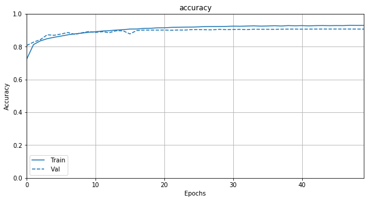

```python
#Plotting accuracy
plt.figure(figsize=(10, 5))
plotter_loss = tfdocs.plots.HistoryPlotter()
plotter_loss.plot({"": history}, metric = "accuracy")
plt.title("accuracy")
plt.ylim([0,1])
```

```
(0.0, 1.0)
```

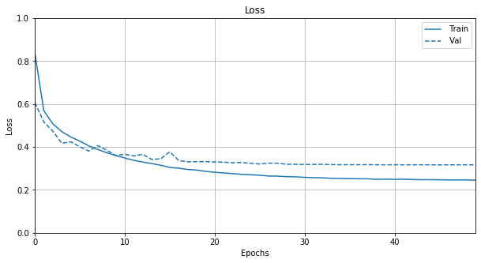

```python
#Plotting loss
plt.figure(figsize=(10, 5))
plotter_loss = tfdocs.plots.HistoryPlotter()
plotter_loss.plot({"": history}, metric = "loss")
plt.title("Loss")
plt.ylim([0,1])
```

```python
#Base model accuracy on test dataset
model_eval = model.evaluate(den_test_images, den_test_labels)
```

**Previous base model was overfitting with optimizer RMSProp (lr = 0.001), two hidden layers including output layer with 256 units each. This model acheived accuracy of 0.8945 on test dataset. Since the model overfitted, multiple combination of dropout rate, learning rate scheduler, and regularlization (l2) was tried. Model with dropout rate 0.2, learning rate and regularization (l2) of 0.0001 provided more stable model. Also, echo steps were calculated using default formula (image count/batch size) and added to the model. After ~20 epochs this model starts overfitting.**

### ConvNet from scratch

###### 1.2.1 Preprocess images

```python
#Reshaping and normalizing training and test images
con_train_images = train_images.reshape((-1, 28,28,1))
con_train_images = con_train_images.astype('float32')/255
con_test_images = test_images.reshape((-1,28,28,1))
con_test_images = con_test_images.astype('float32')/255

#Standardizing training and test images
con_train_images = (con_train_images-(con_train_images.mean()))/(con_train_images.std())
con_test_images = (con_test_images-(con_test_images.mean()))/(con_test_images.std())

#1-hot-coding for labels
con_train_labels = to_categorical(train_labels)
con_test_labels = to_categorical(test_labels)
```

```python
#Splitting training data into training and validation dataset
from sklearn.model_selection import train_test_split
X_train_con, X_val_con, Y_train_con, Y_val_con = train_test_split(con_train_images, con_train_labels, test_size = 0.1, random_state = 12000)

#Constructing tensorflow input pipeline
con_train_dataset = tf.data.Dataset.from_tensor_slices((X_train_con, Y_train_con))
con_train_dataset = con_train_dataset.shuffle(buffer_size=512, seed=14).batch(512)

con_test_dataset = tf.data.Dataset.from_tensor_slices((con_test_images, con_test_labels))
con_test_dataset = con_test_dataset.batch(512)

con_val_dataset = tf.data.Dataset.from_tensor_slices((X_val_con, Y_val_con))
con_val_dataset = con_val_dataset.batch(512)
```

###### 1.2.2 Model architecture

```python
def build_model():
  con_model = models.Sequential()
  con_model.add(layers.Conv2D(filters=32, kernel_size=(3, 3), activation='relu', strides=1, padding='same',
                  data_format='channels_last', input_shape=(28,28,1)))
  con_model.add(layers.BatchNormalization())
  con_model.add(layers.Conv2D(filters=32, kernel_size=(3, 3), activation='relu', strides=1, padding='same',
                  data_format='channels_last'))
  con_model.add(layers.BatchNormalization())
  con_model.add(layers.Dropout(0.5))
  con_model.add(layers.Conv2D(filters=64, kernel_size=(3, 3), activation='relu', strides=1, padding='same',
                  data_format='channels_last'))
  con_model.add(layers.MaxPooling2D(pool_size=(2, 2)))
  con_model.add(layers.Dropout(0.5))
  con_model.add(layers.Conv2D(filters=128, kernel_size=(3, 3), activation='relu', strides=1, padding='same',
                  data_format='channels_last'))
  con_model.add(layers.BatchNormalization())
  con_model.add(layers.Dropout(0.5))
  con_model.add(layers.Flatten())
  con_model.add(layers.Dense(512, activation='relu'))
  con_model.add(layers.BatchNormalization())
  con_model.add(layers.Dropout(0.5))
  con_model.add(layers.Dense(128, activation='relu'))
  con_model.add(layers.BatchNormalization())
  con_model.add(layers.Dropout(0.3))
  con_model.add(layers.Dense(10, activation='softmax'))

  return con_model

con_model = build_model()
con_model.summary()
```

```
Model: "sequential_2"
_________________________________________________________________
Layer (type)                 Output Shape              Param #
=================================================================
conv2d (Conv2D)              (None, 28, 28, 32)        320
_________________________________________________________________
batch_normalization (BatchNo (None, 28, 28, 32)        128
_________________________________________________________________
conv2d_1 (Conv2D)            (None, 28, 28, 32)        9248
_________________________________________________________________
batch_normalization_1 (Batch (None, 28, 28, 32)        128
_________________________________________________________________
dropout_4 (Dropout)          (None, 28, 28, 32)        0
_________________________________________________________________
conv2d_2 (Conv2D)            (None, 28, 28, 64)        18496
_________________________________________________________________
max_pooling2d (MaxPooling2D) (None, 14, 14, 64)        0
_________________________________________________________________
dropout_5 (Dropout)          (None, 14, 14, 64)        0
_________________________________________________________________
conv2d_3 (Conv2D)            (None, 14, 14, 128)       73856
_________________________________________________________________
batch_normalization_2 (Batch (None, 14, 14, 128)       512
_________________________________________________________________
dropout_6 (Dropout)          (None, 14, 14, 128)       0
_________________________________________________________________
flatten (Flatten)            (None, 25088)             0
_________________________________________________________________
dense_6 (Dense)              (None, 512)               12845568
_________________________________________________________________
batch_normalization_3 (Batch (None, 512)               2048
_________________________________________________________________
dropout_7 (Dropout)          (None, 512)               0
_________________________________________________________________
dense_7 (Dense)              (None, 128)               65664
_________________________________________________________________
batch_normalization_4 (Batch (None, 128)               512
_________________________________________________________________
dropout_8 (Dropout)          (None, 128)               0
_________________________________________________________________
dense_8 (Dense)              (None, 10)                1290
=================================================================
Total params: 13,017,770
Trainable params: 13,016,106
Non-trainable params: 1,664
_________________________________________________________________
```